[O’Hara on GitHub](https://github.com/oharac)

# Set up base rasters

Compiled on Fri Sep 15 12:39:59 2023 by ohara

```r
knitr::opts_chunk$set(echo = TRUE, message = FALSE, warning = FALSE)

library(terra)
library(sf)
library(tidyverse)
library(here)
source(here('common_fxns.R'))
```

# 1 Summary

Set up rasters for analysis.

- Master rasters at 1 x 1 km resolution in BC Albers (epsg:3005) CRS
- Ocean presence raster $\in$ (0, 1], 1 km x 1 km BC CRS
  - create bc raster from NE ocean
- Coastal presence raster $\in$ (0, 1], 1 km x 1 km BC CRS
  - create bc raster from buffered land, at 3 nmi distance
- Using the 1 km x 1 km ocean presence raster as a base, create:
  - EEZ raster
  - MEOW raster
  - Bathymetry raster (to clip species to max depth levels)

# 2 Data

Land and ocean shapefiles from Natural Earth. Free vector and raster map data @ naturalearthdata.com.

# 3 Methods

## 3.1 Master raster 1 km resolution

This will be a raster of the BC EEZ, presence = 1 for region, NA for outside the region.

```r
ocean_1km_file <- here('_spatial/ocean_bc_1km.tif')

if(!file.exists(ocean_1km_file)) {

  bc_eez_sf <- read_sf(here('_spatial/bc_eez/bc_eez.gpkg'))
  bc_ext <- ext(bc_eez_sf)
  bc_bbox_r <- rast(bc_ext) %>%
    setValues(1)
  crs(bc_bbox_r) <- crs(bc_eez_sf)

  bc_roi_1km <- project(bc_bbox_r, y = crs(bc_eez_sf), res = 1000)
  rast_bc <- bc_roi_1km %>%
    mask(bc_eez_sf) %>%
    trim() ### cut out excessive NA space in region of interest

  writeRaster(rast_bc, ocean_1km_file, overwrite = TRUE)
}
```

## 3.2 Ocean presence raster

- Reproject NE ocean shapefile to BC CRS
- Use `terra::rasterize` to rasterize the reprojected ocean shapefile to BC CRS with a 1 km resolution.
  - Values will be 1 (ocean) and NA (not ocean)

```r
### load ocean base and land for next steps
ocean_base <- rast(ocean_1km_file)

land_bc_sf <- read_sf(here('_spatial', 'bc_eez', 'bc_land.gpkg'))
```

## 3.3 Coastal zone rasters

- Reproject NE land shapefile to BC CRS. Buffer to 3 nmi.
- Use `rasterize` to rasterize the reprojected buffered land shapefile to BC CRS with a 1 km resolution.
  - Values will be 1 (land) and NA (not land).
- Mask with the ocean 1 km raster to include only ocean-based cells that fall within the 3 nmi buffer.

```r
coastal_3nmi_buffer_1km_file <- here('_spatial/coastal_3nmi_buffer_bc_1km.tif')

if(!file.exists(coastal_3nmi_buffer_1km_file)) {
  message('Processing 3 nmi coastal buffer at 1 km resolution...')

  land_3nmi_bc_sf <- land_bc_sf %>%
    st_buffer(dist = 5556) %>% ### 3 nautical miles = 5.556 km
    st_cast('MULTIPOLYGON') %>%
    mutate(val = 1)

  land_3nmi_bc_1km <- rasterize(land_3nmi_bc_sf,
                              ocean_base,
                              field = 'val',
                              background = NA)

  coastal_3nmi_buffer_1km <- mask(land_3nmi_bc_1km, ocean_base)

  writeRaster(coastal_3nmi_buffer_1km,
              filename = coastal_3nmi_buffer_1km_file)
}
```

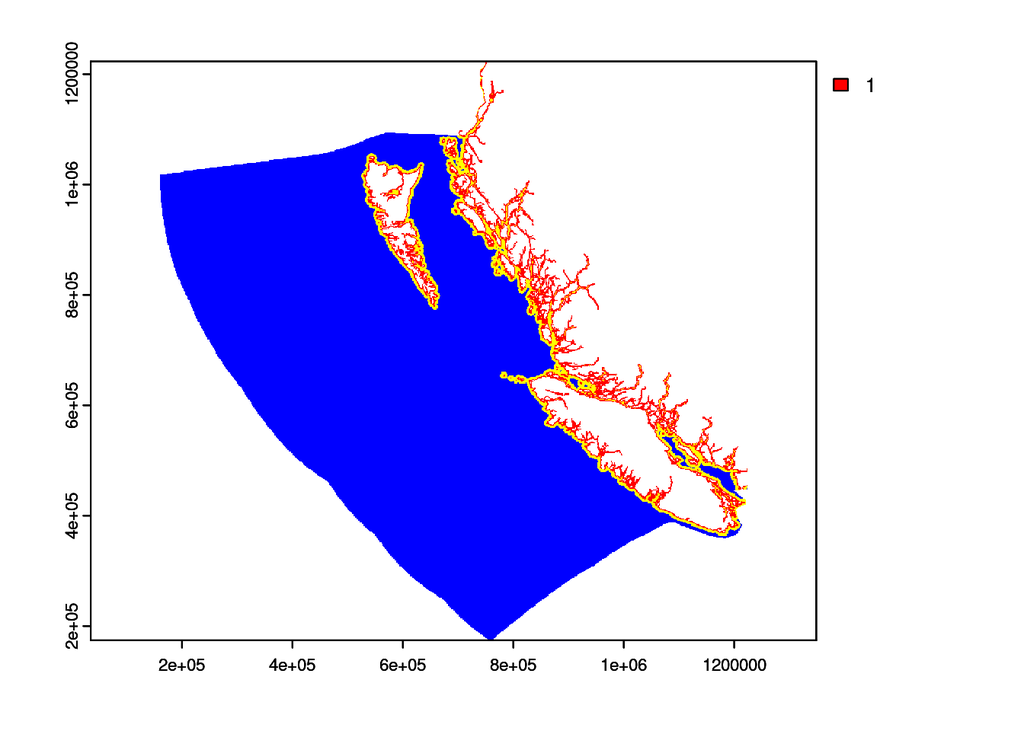

```r
coastal_1km_buffer_1km_file <- here('_spatial/coastal_1km_buffer_bc_1km.tif')

if(!file.exists(coastal_1km_buffer_1km_file)) {
  message('Processing 1 km coastal buffer at 1 km resolution...')

  land_1km_bc_sf <- land_bc_sf %>%
    st_buffer(dist = 1000) %>% ###
    st_cast('MULTIPOLYGON') %>%
    mutate(val = 1)

  land_1km_bc_1km <- rasterize(land_1km_bc_sf,
                              ocean_base,
                              field = 'val',
                              background = NA)

  coastal_1km_buffer_1km <- mask(land_1km_bc_1km, ocean_base)

  writeRaster(coastal_1km_buffer_1km,
              filename = coastal_1km_buffer_1km_file)
}

coastal_3nmi_bc <- rast(coastal_3nmi_buffer_1km_file)
coastal_1km_bc <- rast(coastal_1km_buffer_1km_file)
plot(ocean_base, col = 'blue')
plot(coastal_3nmi_bc, col = 'yellow', add = TRUE)
plot(coastal_1km_bc, col = 'red', add = TRUE)
```

## 3.4 LOICZID raster

for projecting AquaMaps to BC CRS. Because LOICZID starts at 1 at (-180, 90), we can fill in values down to 60N, then project, and it should still work fine.

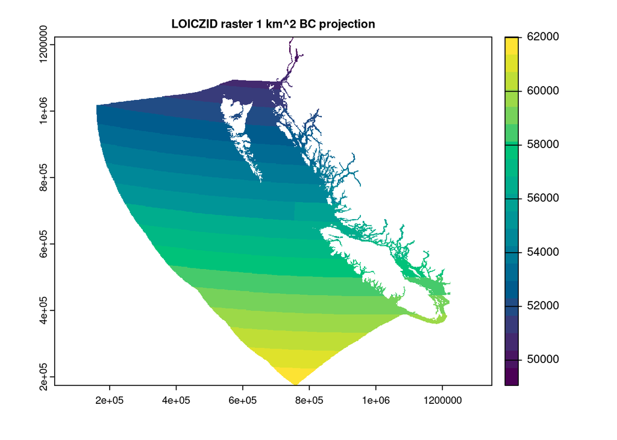

```r
loiczid_rast_file <- here('_spatial', 'loiczid_bc_1km.tif')

if(!file.exists(loiczid_rast_file)) {

  loiczid_rast <- rast(x = ext(c(-180, 180, -90, 90)),
                       res = 0.5,
                       crs = '+init=epsg:4326') %>%
    setValues(1:ncell(.))

  loiczid_bc <- project(loiczid_rast, ocean_base, method = 'near') %>%
    mask(ocean_base)

  writeRaster(loiczid_bc, loiczid_rast_file, overwrite = TRUE)
}

loiczid_bc <- rast(loiczid_rast_file)
plot(loiczid_bc,
     col = hcl.colors(20),
     main = 'LOICZID raster 1 km^2 BC projection')
```

## 3.5 MEOW raster

Using the MEOW shapefile, we will include all the shapes at the region and province level and then mask out land using the area raster (for consistency).

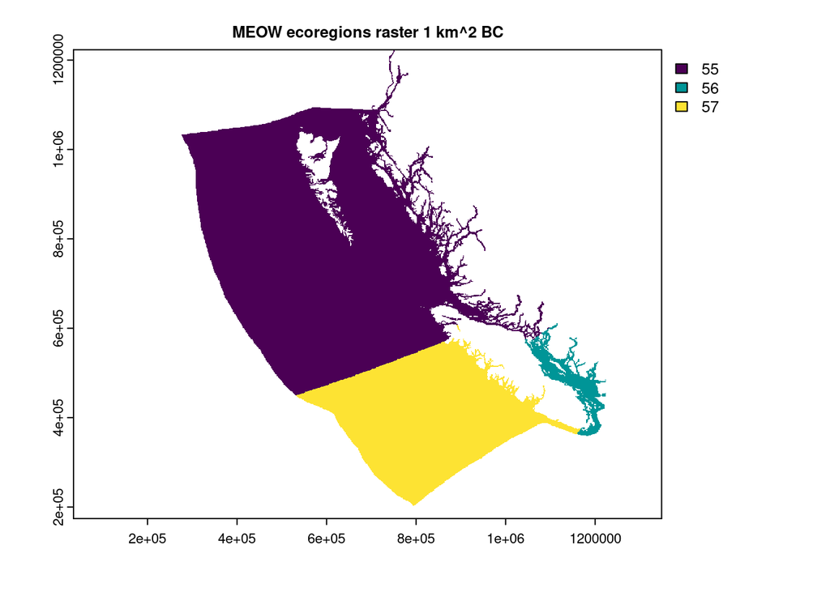

```r
meow_rgn_rast_file <- here('_spatial', 'meow_rgns_bc_1km.tif')

if(!file.exists(meow_rgn_rast_file)) {
  meow_sf <- read_sf(here('_spatial/meow_rgns/meow_rgns.shp'))

  meow_sf_bc <- meow_sf %>%
    smoothr::densify(max_distance = 0.1) %>%
    select(ECO_CODE_X, geometry) %>%
    st_transform(crs(ocean_base))

  # plot(meow_sf_bc)

  meow_rast <- rasterize(meow_sf_bc,
                         ocean_base,
                         field = 'ECO_CODE_X',
                         fun = 'min')

  meow_rast <- meow_rast %>%
    mask(ocean_base)

  writeRaster(meow_rast, meow_rgn_rast_file, overwrite = TRUE)
}

meow_rgn_rast <- rast(meow_rgn_rast_file)

plot(meow_rgn_rast,  col = hcl.colors(20),
     main = 'MEOW ecoregions raster 1 km^2 BC')
```

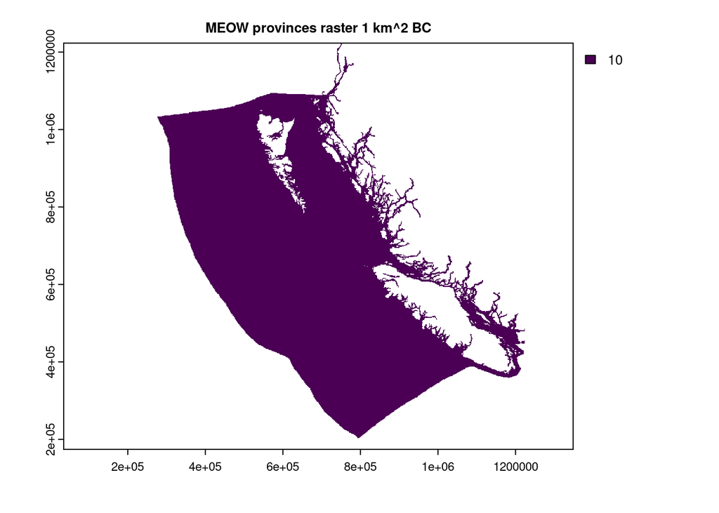

```r
meow_prov_rast_file <- here('_spatial', 'meow_prov_bc_1km.tif')

if(!file.exists(meow_prov_rast_file)) {
  meow_sf <- read_sf(here('_spatial/meow_rgns/meow_rgns.shp'))

  meow_sf_bc <- meow_sf %>%
    smoothr::densify(max_distance = 0.1) %>%
    select(PROV_CODE, geometry) %>%
    st_transform(crs(ocean_base))

  meow_rast <- rasterize(meow_sf_bc,
                         ocean_base,
                         field = 'PROV_CODE', fun = 'min')

  meow_rast <- meow_rast %>%
    mask(ocean_base)

  writeRaster(meow_rast, meow_prov_rast_file, overwrite = TRUE)
}

meow_prov_rast <- rast(meow_prov_rast_file)

plot(meow_prov_rast, col = hcl.colors(20),
     main = 'MEOW provinces raster 1 km^2 BC')
```

## 3.6 Bathymetry raster

Using [General Bathymetric Chart of the Oceans (GEBCO) bathymetry raster](https://www.bodc.ac.uk/data/hosted_data_systems/gebco_gridded_bathymetry_data/), identify min depth of ocean cells. For neritic and coastal cells, leaving as min depth allows for changing depth thresholds if desired. We will not clip based on anything below 200 m, so can classify these more coarsely.

Additionally, to ensure some minimum coastal cell presence, we will include a buffer based on the 3nm coastal zone from OHI.

Bathymetry is masked to the ocean area raster.

### 3.6.1 Create and view minimum depth raster

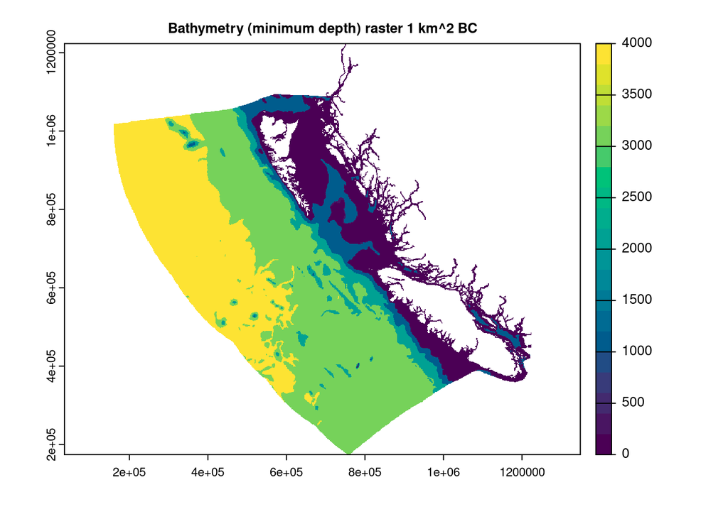

```r
bathy_rast_file <- here('_spatial', 'bathy_bc.tif')

if(!file.exists(bathy_rast_file)) {

  gebco_rast_file <- here_anx('_spatial/gebco/GRIDONE_1D.nc')
  gebco_rast_raw  <- rast(gebco_rast_file)

  ### The GEBCO raster is elevation, so depth is neg... for min depth,
  ### aggregate by max (and vice versa) (no need to aggregate for 1 km resolution)
  bathy_rast_min <- gebco_rast_raw

  bathy_rast_min <- -1 * bathy_rast_min ### depth as positive

  bathy_rast_raw <- bathy_rast_min %>%
    project(ocean_base, method = 'near')

  ### reclassify:
  ### compress cells above zero to sea level;
  ### compress cells below 200 m to rough depth clips
  bathy_rast <- bathy_rast_raw
  bathy_rast[bathy_rast_raw <    0] <-    0
  bathy_rast[bathy_rast_raw >  200] <- 1000
  bathy_rast[bathy_rast_raw > 1000] <- 2000
  bathy_rast[bathy_rast_raw > 2000] <- 3000
  bathy_rast[bathy_rast_raw > 3000] <- 4000
  bathy_rast[bathy_rast_raw > 4000] <- 5000
  bathy_rast[bathy_rast_raw > 5000] <- 6000
  bathy_rast[bathy_rast_raw > 6000] <- 7000
  bathy_rast[bathy_rast_raw > 7000] <- 8000

  bathy_rast <- bathy_rast %>%
    mask(ocean_base)

  writeRaster(bathy_rast, bathy_rast_file, overwrite = TRUE)

  ### set up all masks with a base filled with NAs
  coastal_rast <- rast(coastal_3nmi_buffer_1km_file)
  rast_neritic <- rast_shallow <- rast(bathy_rast)
  rast_neritic[bathy_rast <= 200] <- 1
  rast_neritic[!is.na(coastal_rast)] <- 1
  rast_shallow[bathy_rast <=  60] <- 1
  rast_shallow[!is.na(coastal_rast)] <- 1

  writeRaster(rast_neritic, here('_spatial', 'bathy_bc_neritic.tif'),
              overwrite = TRUE)
  writeRaster(rast_shallow, here('_spatial', 'bathy_bc_shallow.tif'),
              overwrite = TRUE)

}

bathy_rast <- rast(bathy_rast_file)

plot(bathy_rast,  col = hcl.colors(20),
     main = 'Bathymetry (minimum depth) raster 1 km^2 BC')
```